# Evidencia 2 | Proyecto Integrador

Biniza Verónica Vázquez Moreno A01737294

2026-04-29

## Carga de secuencias

Cargamos las secuencias de ARN del SARS-CoV-2 a partir de los archivos FASTA descargados, utilizando la función `read_project_fastas()` definida en el bloque de configuración. Esto nos permitirá tener un objeto `DNAStringSet` con todas las secuencias organizadas y listas para su análisis.

```r
sequences <- read_project_fastas()
sequences
```

```
## DNAStringSet object of length 49:
##      width seq                                              names
##  [1] 29763 AGATCTGTTCTCTAAACGAACTT...ATTAATTTTAGTAGTGCTATCC USA_WT
##  [2] 29855 ATTAAAGGTTTATACCTTTCCAG...CTTCTTAGGAGAATGACAAAAA RaTG13_RaTG13
##  [3] 29885 ATTAAAGGTTTATACCTTCCCAG...AAAAAAAAAAAAAAAAAAAAAA GHA_WT
##  [4] 29873 ATTAAAGGTTTATACCTTCCTAG...AAAAAAAAAAAAAAAAAAAAAA HKG_WT
##  [5] 29784 CTTTCGATCTCTTGTAGATCTGT...ATTAATTTTAGTAGTGCTATCC THA_WT
##  ...   ... ...
## [45] 29521 CACGCAGTATAATTAATAACTAA...AGAGCCACCACATTTTCACCGA MT121216.1 Pangol...
## [46] 29856 TTAAAGGTTTATACCTTCCCAGG...GTGATTTTAATAGCTTCTTAGG OR578388.1 |Sever...
## [47] 29441 GCTCGTACGTGGCTTTGGAGACT...ATTAATTTTAGTAGTGCTATCC ON835143.1 Severe...
## [48] 29792 CTTTCGATCTCTTGTAGATCTGT...ATCCCCATGTGATTTTAATAGC MZ611975.1 Severe...
## [49] 29903 ATTAAAGGTTTATACCTTCCCAG...AAAAAAAAAAAAAAAAAAAAAA NC_045512.2 Sever...
```

## Cálculo de la longitud de las secuencias de cada variante

Una vez cargadas las secuencias, calculamos la longitud de cada una utilizando la función `width()` de Biostrings, que devuelve el número de nucleótidos en cada secuencia. Esto nos permitirá comparar las longitudes entre las diferentes variantes y detectar posibles anomalías o diferencias significativas.

Usamos `width()` ya que es la función específica para objetos `DNAStringSet` y es más eficiente que otras alternativas para este tipo de datos.

```r
## LONGITUDES
cat("Sequence lengths:\n")
```

```
## Sequence lengths:
```

```r
for (i in seq_along(sequences)) {
    cat(names(sequences)[i], ":", width(sequences)[i], "\n")
}
```

```
## USA_WT : 29763
## RaTG13_RaTG13 : 29855
## GHA_WT : 29885
## HKG_WT : 29873
## THA_WT : 29784
## DEU_Beta : 29827
## FRA_Omicron : 29804
## ITA_WT : 29868
## USA_WT : 29441
## LBY_WT : 29604
## MYS_WT : 29780
## MEX_WT : 29855
## BEL_WT : 29684
## HKG_WT : 29873
## USA_WT : 29646
## HKG_WT : 29873
## USA_WT : 29441
## IND_WT : 29784
## Pangolin_Pangolin : 29521
## USA_WT : 29441
## Wuhan_Original : 29903
## MW422255.1 Severe acute respiratory syndrome coronavirus 2 isolate SARS-CoV-2/human/USA/SEARCH-5574-SAN/2020, complete genome : 29763
## OR075030.1 Severe acute respiratory syndrome coronavirus 2 isolate SARS-CoV-2/human/ARG/Cordoba-V5D3-0706/2021 ORF1ab polyprotein (ORF1ab), ORF1a polyprotein (ORF1ab), surface glycoprotein (S), ORF3a protein (ORF3a), envelope protein (E), membrane glycoprotein (M), ORF6 protein (ORF6), ORF7a prot…
## MN996532.2 Bat coronavirus RaTG13, complete genome : 29855
## MW598419.1 Severe acute respiratory syndrome coronavirus 2 isolate SARS-CoV-2/human/GHA/nmimr-SARS-CoV-2-TRA-201/2021, complete genome : 29885
## OM212472.1 Severe acute respiratory syndrome coronavirus 2 isolate SARS-CoV-2/human/HKG/HKU-691/2021, complete genome : 29873
## PQ281325.1 Severe acute respiratory syndrome coronavirus 2 isolate SARS-CoV-2/human/BRA/278/2023 ORF1ab polyprotein (ORF1ab), ORF1a polyprotein (ORF1ab), and surface glycoprotein (S) genes, complete cds; ORF3a gene, complete sequence; envelope protein (E), membrane glycoprotein (M), and ORF6 prot…
## MW064261.1 Severe acute respiratory syndrome coronavirus 2 isolate SARS-CoV-2/human/CHL/op31d5/2020 ORF1ab polyprotein (ORF1ab), ORF1a polyprotein (ORF1ab), surface glycoprotein (S), ORF3a protein (ORF3a), envelope protein (E), membrane glycoprotein (M), ORF6 protein (ORF6), ORF7a protein (ORF7a)…
## MZ888545.1 Severe acute respiratory syndrome coronavirus 2 isolate SARS-CoV-2/human/THA/AFRIMS-COV1904/2021 ORF1ab polyprotein (ORF1ab), ORF1a polyprotein (ORF1ab), surface glycoprotein (S), ORF3a protein (ORF3a), envelope protein (E), membrane glycoprotein (M), ORF6 protein (ORF6), ORF7a protein…
## MZ314998.1 Severe acute respiratory syndrome coronavirus 2 isolate SARS-CoV-2/human/DEU/SARS-CoV-2_B.1.351_VeroE6_210226_P4/2021, complete genome : 29827
## OQ630013.1 Severe acute respiratory syndrome coronavirus 2 isolate SARS-CoV-2/human/ECU/Ecu4297/2022 ORF1ab polyprotein (ORF1ab), ORF1a polyprotein (ORF1ab), and surface glycoprotein (S) genes, partial cds; and ORF3a protein (ORF3a), envelope protein (E), membrane glycoprotein (M), ORF6 protein (…
## MT594402.1 Severe acute respiratory syndrome coronavirus 2 isolate SARS-CoV-2/human/FRA/BavPat1/2020, complete genome : 29804
## MW642248.1 Severe acute respiratory syndrome coronavirus 2 isolate SARS-CoV-2/human/ITA/ABR-IZSGC-TE30939/2021, complete genome : 29868
## BS016095.1 |Severe acute respiratory syndrome coronavirus 2 SARS-CoV-2/human/Japan/sb_ncgm_sars_cov_2_08362/2021 RNA, complete genome : 29763
## ON835143.1 Severe acute respiratory syndrome coronavirus 2 isolate SARS-CoV-2/human/USA/CO-CDPHE-36831863/2022 ORF1ab polyprotein (ORF1ab) and ORF1a polyprotein (ORF1ab) genes, partial cds; surface glycoprotein (S), ORF3a protein (ORF3a), envelope protein (E), membrane glycoprotein (M), ORF6 prot…
## MZ054888.1 Severe acute respiratory syndrome coronavirus 2 isolate SARS-CoV-2/human/LBY/BTRC Libya SARS-CoV-2 WGS-32/2021 ORF1ab polyprotein (ORF1ab), ORF1a polyprotein (ORF1ab), surface glycoprotein (S), ORF3a protein (ORF3a), envelope protein (E), membrane glycoprotein (M), ORF6 protein (ORF6),…
## OK594615.1 Severe acute respiratory syndrome coronavirus 2 isolate SARS-CoV-2/human/MYS/UG896/2020 ORF1ab polyprotein (ORF1ab) gene, partial cds; ORF1a polyprotein (ORF1ab) gene, complete cds; surface glycoprotein (S) gene, partial cds; ORF3a protein (ORF3a), envelope protein (E), membrane glycop…
## MW595908.1 Severe acute respiratory syndrome coronavirus 2 isolate SARS-CoV-2/human/MEX/CICESE-BC5/2020, complete genome : 29855
## OL672836.1 Severe acute respiratory syndrome coronavirus 2 isolate SARS-CoV-2/human/BEL/rega-20174/2021, complete genome : 29684
## OM212472.1 Severe acute respiratory syndrome coronavirus 2 isolate SARS-CoV-2/human/HKG/HKU-691/2021, complete genome : 29873
## OV111738.1 Severe acute respiratory syndrome coronavirus 2 genome assembly, chromosome: 1 : 29646
## OM212472.1 Severe acute respiratory syndrome coronavirus 2 isolate SARS-CoV-2/human/HKG/HKU-691/2021, complete genome : 29873
## ON835143.1 Severe acute respiratory syndrome coronavirus 2 isolate SARS-CoV-2/human/USA/CO-CDPHE-36831863/2022 ORF1ab polyprotein (ORF1ab) and ORF1a polyprotein (ORF1ab) genes, partial cds; surface glycoprotein (S), ORF3a protein (ORF3a), envelope protein (E), membrane glycoprotein (M), ORF6 prot…
## MZ724481.1 Severe acute respiratory syndrome coronavirus 2 isolate SARS-CoV-2/human/IND/hospital_2_319/2021 ORF1ab polyprotein (ORF1ab), ORF1a polyprotein (ORF1ab), surface glycoprotein (S), ORF3a protein (ORF3a), envelope protein (E), membrane glycoprotein (M), and ORF6 protein (ORF6) genes, com…
## MT121216.1 Pangolin coronavirus isolate MP789, complete genome : 29521
## OR578388.1 |Severe acute respiratory syndrome coronavirus 2 isolate SARS-CoV-2/human/CHE/SARS-CoV-2 Gamma 5051/2021, complete genome : 29856
## ON835143.1 Severe acute respiratory syndrome coronavirus 2 isolate SARS-CoV-2/human/USA/CO-CDPHE-36831863/2022 ORF1ab polyprotein (ORF1ab) and ORF1a polyprotein (ORF1ab) genes, partial cds; surface glycoprotein (S), ORF3a protein (ORF3a), envelope protein (E), membrane glycoprotein (M), ORF6 prot…
## MZ611975.1 Severe acute respiratory syndrome coronavirus 2 isolate SARS-CoV-2/human/VEN/Zul6567/2021 ORF1ab polyprotein (ORF1ab), ORF1a polyprotein (ORF1ab), surface glycoprotein (S), ORF3a protein (ORF3a), envelope protein (E), membrane glycoprotein (M), ORF6 protein (ORF6), ORF7a protein (ORF7a…
## NC_045512.2 Severe acute respiratory syndrome coronavirus 2 isolate Wuhan-Hu-1, complete genome : 29903
```

## Gráfico comparativo de las secuencias

Para visualizar las diferencias entre las secuencias de ARN de las distintas variantes, creamos un gráfico comparativo utilizando `ggplot2`. Este gráfico muestra la composición de bases (A, C, G, T) de cada secuencia, lo que nos ayuda a identificar patrones o tendencias entre las variantes y a detectar posibles mutaciones o cambios en la composición genética relacionados con diferencias en transmisibilidad o virulencia.

- `do.call()`: Permite ejecutar una función con una lista de argumentos, útil para combinar los resultados de múltiples secuencias en un solo data frame.
- `lapply()`: Aplica una función a cada elemento de una lista.
- `strsplit()`: Divide una cadena de texto en caracteres individuales.
- `table()`: Crea una tabla de frecuencias para contar la cantidad de cada base por secuencia.
- `ggplot()`: Función principal de ggplot2 para crear el gráfico facetado comparativo.

> *Usamos `ggplot()` para presentar la composición de bases de todas las variantes en una sola imagen de manera más clara y ordenada. En lugar de generar muchos gráficos separados, se construyó un solo gráfico facetado que agrupa la información por secuencia, facilitando la comparación visual entre variantes.*

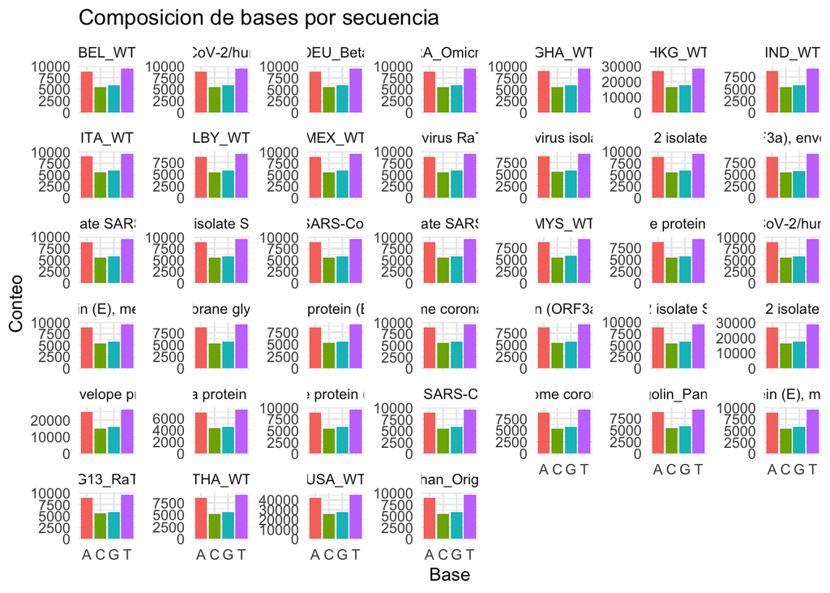

```r
# FUNCIONES PARA COMPARAR SECUENCIAS
compara_all <- function(seq_set) {
    base_levels <- c("a", "c", "g", "t")
    plot_data <- do.call(
        rbind,
        lapply(seq_along(seq_set), function(i) {
            seq_chars <- tolower(strsplit(as.character(seq_set[[i]]), "")[[1]])
            seq_table <- table(factor(seq_chars, levels = base_levels))

            data.frame(
                sequence = names(seq_set)[i],
                base = c("A", "C", "G", "T"),
                count = as.numeric(seq_table)
            )
        })
    )

    composition_plot <- ggplot(
        plot_data,
        aes(x = base, y = count, fill = base)
    ) +
        geom_col() +
        facet_wrap(~sequence, scales = "free_y") +
        labs(
            title = "Composicion de bases por secuencia",
            x = "Base",
            y = "Conteo"
        ) +
        theme_minimal() +
        theme(legend.position = "none")

    composition_plot
}

# FUNC EN ACTION
composition_plot <- compara_all(sequences)
print(composition_plot)
```

```r
ggsave(
    filename = "comparacion_fasta.png",
    plot = composition_plot,
    width = 12,
    height = 16,
    dpi = 150,
    path = getwd()
)
```

## Análisis de composición de bases y contenido AT y GC

Calculamos el porcentaje de GC y AT para cada secuencia utilizando la función `letterFrequency()` de Biostrings, que cuenta la frecuencia de cada base en las secuencias. Luego, se crea una tabla con esta información para facilitar su análisis y visualización.

```r
base_freq <- Biostrings::letterFrequency(
    sequences,
    letters = c("A", "C", "G", "T"),
    as.prob = TRUE
)

tabla_bases <- data.frame(
    VarID = paste0("Var", seq_along(sequences)),
    Variante = names(sequences),
    GC_Content = rowSums(base_freq[, c("G", "C"), drop = FALSE]) * 100,
    AT_Content = rowSums(base_freq[, c("A", "T"), drop = FALSE]) * 100,
    check.names = FALSE
)

tabla_bases
```

```
##    VarID
## 1   Var1
## 2   Var2
## 3   Var3
## 4   Var4
## 5   Var5
## 6   Var6
## 7   Var7
## 8   Var8
## 9   Var9
## 10 Var10
## 11 Var11
## 12 Var12
## 13 Var13
## 14 Var14
```

[output cut: 135 more lines]

Y graficamos con ayuda de `ggplot2` el contenido de AT y CG por variante, usando la etiqueta corta `VarN` para que los nombres largos no oculten la visualización.

#### Gráfico de contenido AT por variante

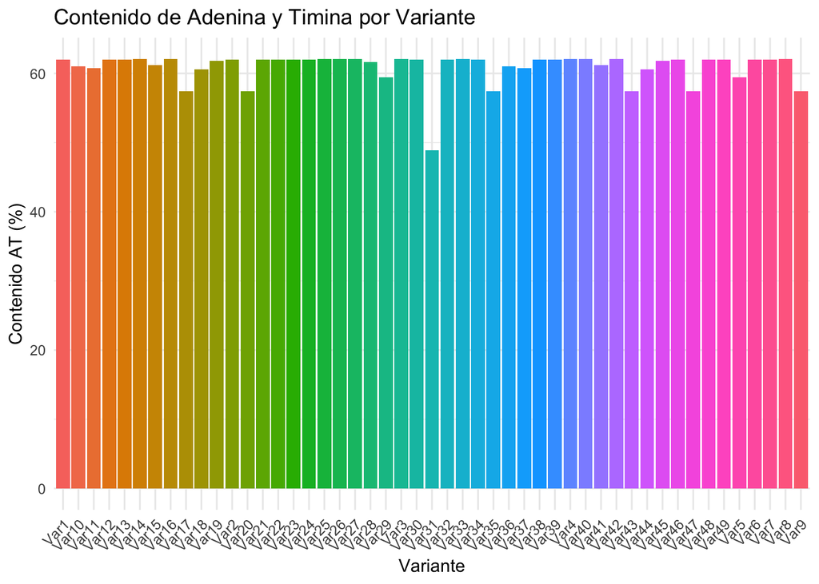

```r
p <- ggplot(
    tabla_bases,
    aes(x = VarID, y = AT_Content, fill = VarID)
) +
    geom_col() +
    theme_minimal() +
    labs(
        title = "Contenido de Adenina y Timina por Variante",
        x = "Variante",
        y = "Contenido AT (%)"
    ) +
    theme(axis.text.x = element_text(angle = 45, hjust = 1))
p <- p + scale_fill_hue(guide = "none")
print(p)
```

#### Gráfico de contenido GC por variante

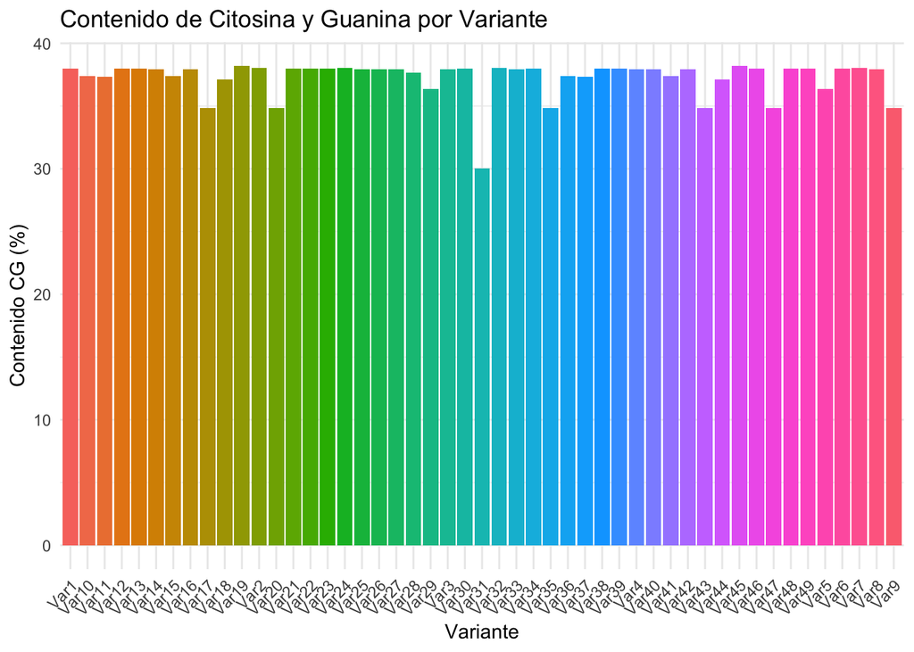

```r
p <- ggplot(
    tabla_bases,
    aes(x = VarID, y = GC_Content, fill = VarID)
) +
    geom_col() +
    theme_minimal() +
    labs(
        title = "Contenido de Citosina y Guanina por Variante",
        x = "Variante",
        y = "Contenido CG (%)"
    ) +
    theme(axis.text.x = element_text(angle = 45, hjust = 1))
p <- p + scale_fill_hue(guide = "none")
print(p)
```